# MaxDiff Analysis of MSBA Class Preferences

Counts, MLE, and Bayesian estimation of the MNL model

Author

Published

May 21, 2026

## Introduction

This post analyzes data from a **Best-Worst Scaling** (MaxDiff) survey in which MSBA students ranked their preferences across the 10 core MSBA courses at UCSD Rady.

**What is MaxDiff?** MaxDiff is a survey methodology designed to measure relative preferences with high precision. On each screen of the survey, respondents see a small subset of items — here, 4 classes — and select both the *most preferred* and the *least preferred* from that set. They repeat this across many screens, each showing a different combination of items. The resulting data reveal how much respondents prefer each item relative to every other.

**Why not just use a 1–10 rating scale?** Humans are surprisingly good at making comparative trade-offs (“which is best, which is worst?”) but notoriously inconsistent when assigning numbers to abstract concepts. Rating scales suffer from *scale-use bias* — some people anchor at 7, others at 5 — making cross-respondent comparisons unreliable. MaxDiff sidesteps this by forcing real choices: every “best” pick reveals information about the three items that were *not* picked, giving us far more signal per question.

**The 10 items** here are the 10 core MSBA courses. Our goal is to estimate each course’s relative preference using three methods of increasing sophistication:

1. **Counts analysis** — a fast, intuitive score based on raw pick frequencies
2. **MNL via Maximum Likelihood** — a statistically rigorous point estimate of preference utilities
3. **MNL via Bayesian (MCMC) estimation** — the same model, but returning a full posterior distribution over utilities

All three methods should agree on the broad ranking. They differ in how they quantify preference strength and uncertainty. I expect courses like Machine Learning or the Capstone to rank highly, while more niche electives may cluster in the middle. Let’s find out.

## The Data

```r
library(tidyverse)
library(knitr)
library(kableExtra)

# Read data
df <- read_csv("maxdiff_design_and_choices.csv", show_col_types = FALSE)
labels_raw <- read_csv("maxdiff_item_labels.csv", show_col_types = FALSE)

# Clean up labels
labels <- labels_raw |>
  select(item = `Item #`, label = Item) |>
  filter(!is.na(item)) |>
  mutate(
    short_label = case_when(
      item == 1  ~ "AI Math & Prog.",
      item == 2  ~ "SQL",
      item == 3  ~ "Mktg/Fin/Ops",
      item == 4  ~ "Large Data",
      item == 5  ~ "Business Analytics",
      item == 6  ~ "Analytics Consulting",
      item == 7  ~ "Customer Analytics",
      item == 8  ~ "Capstone",
      item == 9  ~ "Marketing Analytics",
      item == 10 ~ "BI Systems",
      TRUE ~ paste("Item", item)
    )
  )

# Filter to "clean" tasks: exactly 4 items from 1-10, one best, one worst
# Item 11 appears in some tasks (a "none/other" option) - exclude those tasks
clean_df <- df |>
  group_by(`Record ID`, Task) |>
  filter(
    n() == 4,
    all(Item %in% 1:10),
    sum(Response == 1) == 1,
    sum(Response == -1) == 1
  ) |>
  ungroup()

# Basic descriptives
N <- n_distinct(clean_df$`Record ID`)
tasks_per_resp <- clean_df |>
  distinct(`Record ID`, Task) |>
  count(`Record ID`) |>
  pull(n) |>
  unique()
T_per_resp <- tasks_per_resp  # should be 8
J_per_task <- 4
J_total <- 10
total_tasks <- n_distinct(clean_df$`Record ID`, clean_df$Task)

cat("Number of respondents (N):", N, "\n")
```

```
Number of respondents (N): 85
```

```r
cat("Tasks per respondent (T):", T_per_resp, "\n")
```

```
Tasks per respondent (T): 8
```

```r
cat("Items per task (J):", J_per_task, "\n")
```

```
Items per task (J): 4
```

```r
cat("Total items in study:", J_total, "\n")
```

```
Total items in study: 10
```

```r
cat("Total clean tasks:", total_tasks, "\n")
```

```
Total clean tasks: 680
```

**Note on the data:** The raw file contains 15 tasks per respondent, but 7 of those tasks include a special “Item 11” (likely a ‘none of these’ or anchor option) and have fewer than 4 items or no ‘worst’ response. We restrict all analyses to the **680 fully-formed tasks** (4 items each, all from items 1–10, with exactly one best and one worst pick).

```r
# Sanity check: every task has exactly 1 best, 1 worst, 2 neutral
sanity <- clean_df |>
  group_by(`Record ID`, Task) |>
  summarise(
    n_best  = sum(Response == 1),
    n_worst = sum(Response == -1),
    n_zero  = sum(Response == 0),
    n_items = n(),
    .groups = "drop"
  )

stopifnot(all(sanity$n_best == 1))
stopifnot(all(sanity$n_worst == 1))
stopifnot(all(sanity$n_zero == 2))
stopifnot(all(sanity$n_items == 4))

cat("✓ Sanity check passed: every task has exactly 1 best, 1 worst, 2 neutral, 4 items.\n")
```

```
✓ Sanity check passed: every task has exactly 1 best, 1 worst, 2 neutral, 4 items.
```

```r
# How often was each item shown?
exposure <- clean_df |>
  count(Item) |>
  left_join(labels, by = c("Item" = "item")) |>
  arrange(Item)

kable(
  exposure |> select(Item, short_label, n),
  col.names = c("Item #", "Class", "Times Shown"),
  caption = "Exposure count per item across all clean tasks"
) |>
  kable_styling(bootstrap_options = c("striped", "hover"), full_width = FALSE)
```

Exposure count per item across all clean tasks

| Item # | Class | Times Shown |
| --- | --- | --- |
| 1 | AI Math & Prog. | 273 |
| 2 | SQL | 274 |
| 3 | Mktg/Fin/Ops | 272 |
| 4 | Large Data | 276 |
| 5 | Business Analytics | 270 |
| 6 | Analytics Consulting | 267 |
| 7 | Customer Analytics | 276 |
| 8 | Capstone | 272 |
| 9 | Marketing Analytics | 274 |
| 10 | BI Systems | 266 |

The exposure counts are reasonably balanced across items, as expected from a proper MaxDiff design.

## Counts Analysis

The simplest way to summarize MaxDiff data is a **counts score**. For each item $j$, we compute:

$$\text{score}_j = \frac{\text{# times picked best}}{\text{# times shown}} - \frac{\text{# times picked worst}}{\text{# times shown}}$$

A score near +1 means the item is almost always chosen as best when it appears; near −1 means it’s almost always chosen as worst; near 0 means it’s somewhere in the middle. This is intuitive and fast to compute — no model required. The downside is that it ignores *who* the competition was in each task; being picked best when shown alongside weak alternatives inflates the score compared to being picked best in tough company. The MNL model (next section) corrects for this.

```r
counts <- clean_df |>
  group_by(Item) |>
  summarise(
    shown  = n(),
    n_best  = sum(Response == 1),
    n_worst = sum(Response == -1),
    .groups = "drop"
  ) |>
  mutate(
    pct_best  = n_best  / shown,
    pct_worst = n_worst / shown,
    score     = pct_best - pct_worst
  ) |>
  left_join(labels, by = c("Item" = "item")) |>
  arrange(desc(score))

kable(
  counts |>
    select(Item, short_label, shown, n_best, n_worst, pct_best, pct_worst, score) |>
    mutate(across(c(pct_best, pct_worst, score), \(x) round(x, 3))),
  col.names = c("Item #", "Class", "Shown", "# Best", "# Worst",
                "% Best", "% Worst", "Score"),
  caption = "Counts analysis: ranked by score (% best − % worst)"
) |>
  kable_styling(bootstrap_options = c("striped", "hover"), full_width = FALSE)
```

Counts analysis: ranked by score (% best − % worst)

| Item # | Class | Shown | # Best | # Worst | % Best | % Worst | Score |
| --- | --- | --- | --- | --- | --- | --- | --- |
| 9 | Marketing Analytics | 274 | 147 | 12 | 0.536 | 0.044 | 0.493 |
| 5 | Business Analytics | 270 | 93 | 55 | 0.344 | 0.204 | 0.141 |
| 7 | Customer Analytics | 276 | 104 | 71 | 0.377 | 0.257 | 0.120 |
| 4 | Large Data | 276 | 77 | 60 | 0.279 | 0.217 | 0.062 |
| 8 | Capstone | 272 | 72 | 69 | 0.265 | 0.254 | 0.011 |
| 2 | SQL | 274 | 55 | 56 | 0.201 | 0.204 | -0.004 |
| 10 | BI Systems | 266 | 23 | 55 | 0.086 | 0.207 | -0.120 |
| 1 | AI Math & Prog. | 273 | 33 | 90 | 0.121 | 0.330 | -0.209 |
| 3 | Mktg/Fin/Ops | 272 | 43 | 101 | 0.158 | 0.371 | -0.213 |
| 6 | Analytics Consulting | 267 | 33 | 111 | 0.124 | 0.416 | -0.292 |

```r
set.seed(42)

# Bootstrap CIs — resample respondents with replacement
respondents <- unique(clean_df$`Record ID`)
n_boot <- 1000

boot_scores <- matrix(NA, nrow = n_boot, ncol = 10)
colnames(boot_scores) <- 1:10

for (b in 1:n_boot) {
  # Sample respondents with replacement
  sampled_ids <- sample(respondents, length(respondents), replace = TRUE)

  # Build a resampled dataset (need to handle duplicate IDs)
  boot_data <- map_dfr(sampled_ids, \(id) filter(clean_df, `Record ID` == id))

  # Compute scores
  bc <- boot_data |>
    group_by(Item) |>
    summarise(
      shown   = n(),
      n_best  = sum(Response == 1),
      n_worst = sum(Response == -1),
      .groups = "drop"
    ) |>
    mutate(score = (n_best - n_worst) / shown)

  for (j in 1:10) {
    val <- bc$score[bc$Item == j]
    boot_scores[b, as.character(j)] <- if (length(val) > 0) val else NA
  }
}

ci <- apply(boot_scores, 2, quantile, probs = c(0.025, 0.975), na.rm = TRUE)

counts_with_ci <- counts |>
  mutate(
    ci_lo = ci["2.5%",  as.character(Item)],
    ci_hi = ci["97.5%", as.character(Item)]
  )
```

```
`height` was translated to `width`.
```

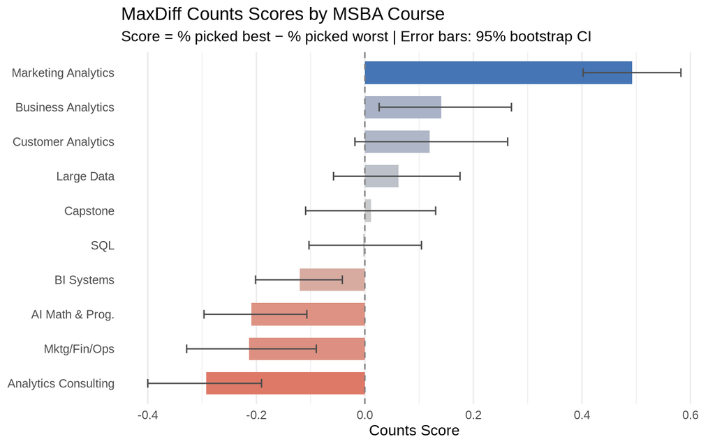

```r
counts_with_ci |>
  mutate(short_label = fct_reorder(short_label, score)) |>
  ggplot(aes(x = score, y = short_label)) +
  geom_col(aes(fill = score), width = 0.65) +
  geom_errorbarh(aes(xmin = ci_lo, xmax = ci_hi), height = 0.25, color = "gray30") +
  geom_vline(xintercept = 0, linetype = "dashed", color = "gray50") +
  scale_fill_gradient2(low = "#d73027", mid = "gray80", high = "#4575b4",
                       midpoint = 0, guide = "none") +
  labs(
    title = "MaxDiff Counts Scores by MSBA Course",
    subtitle = "Score = % picked best − % picked worst | Error bars: 95% bootstrap CI",
    x = "Counts Score",
    y = NULL
  ) +
  theme_minimal(base_size = 12) +
  theme(panel.grid.major.y = element_blank())
```

## From MaxDiff Data to MNL Choices

Before fitting a model, we need to understand how MaxDiff data plugs into the **Multinomial Logit (MNL)** framework.

The MNL model assigns each course $j$ a utility parameter $\beta_j$. When a respondent sees a set of 4 courses $\{a, b, c, d\}$, the probability they pick course $b$ as *best* follows a softmax:

$$P(\text{best} = b) = \frac{\exp(\beta_b)}{\exp(\beta_a) + \exp(\beta_b) + \exp(\beta_c) + \exp(\beta_d)}$$

After picking the best, the respondent picks the *worst* from the remaining 3 items. The key insight: picking “worst” is equivalent to picking *best on a negatively-valued version* — the course with the lowest utility. So we flip the signs and apply softmax again:

$$P(\text{worst} = c \mid \text{best} = b) = \frac{\exp(-\beta_c)}{\exp(-\beta_a) + \exp(-\beta_c) + \exp(-\beta_d)}$$

Each task therefore yields **two** MNL observations: one for the best pick (from 4 items) and one for the worst pick (from the remaining 3). This doubles our data compared to a best-only design.

**Identifiability:** The softmax is invariant to adding a constant to all $\beta$’s — only *differences* between utilities are identified. We fix $\beta_1 = 0$ (AI Math & Programming as reference) and estimate $\beta_2, \ldots, \beta_{10}$. All reported utilities are relative to Item 1.

```r
# Reshape into a compact format: one row per task
# Columns: respondent, task, items (4), best_item, worst_item
task_data <- clean_df |>
  group_by(`Record ID`, Task) |>
  summarise(
    items     = list(Item),
    best_item = Item[Response == 1],
    worst_item = Item[Response == -1],
    .groups = "drop"
  )

# Convert to matrix form for fast likelihood computation
# items_mat: (n_tasks x 4), best_vec, worst_vec
items_mat  <- do.call(rbind, task_data$items)
best_vec   <- task_data$best_item
worst_vec  <- task_data$worst_item

n_tasks <- nrow(task_data)
cat("Total tasks for likelihood:", n_tasks, "\n")
```

```
Total tasks for likelihood: 680
```

```r
cat("Items matrix dim:", dim(items_mat), "\n")
```

```
Items matrix dim: 680 4
```

## MNL via Maximum Likelihood

The log-likelihood sums over all tasks. For each task, we get two terms — one for the best pick and one for the worst pick (from the remaining 3 items, with negated utilities):

$$\ell(\boldsymbol{\beta}) = \sum_{\text{tasks}} \left[ \beta_{j^*_b} - \log\sum_{j \in \text{shown}} \exp(\beta_j) - \beta_{j^*_w} - \log\sum_{j \in \text{shown} \setminus \{j^*_b\}} \exp(-\beta_j) \right]$$

We fix $\beta_1 = 0$ inside the function and estimate 9 free parameters.

```r
# Log-likelihood function
# beta: length-9 vector for items 2-10 (item 1 fixed at 0)
ll <- function(beta, items_mat, best_vec, worst_vec) {
  # Full beta vector with item 1 fixed at 0
  beta_full <- c(0, beta)  # index i corresponds to item i

  loglik <- 0
  n_tasks <- nrow(items_mat)

  for (t in 1:n_tasks) {
    shown    <- items_mat[t, ]       # 4 item indices
    b        <- best_vec[t]          # best item
    w        <- worst_vec[t]         # worst item
    remaining <- shown[shown != b]   # 3 items after removing best

    # Best pick: softmax over 4 items
    utils_shown   <- beta_full[shown]
    log_denom_best <- log(sum(exp(utils_shown - max(utils_shown)))) + max(utils_shown)
    loglik <- loglik + beta_full[b] - log_denom_best

    # Worst pick: softmax with negated utilities over 3 remaining items
    neg_utils_rem  <- -beta_full[remaining]
    log_denom_worst <- log(sum(exp(neg_utils_rem - max(neg_utils_rem)))) + max(neg_utils_rem)
    loglik <- loglik + (-beta_full[w]) - log_denom_worst
  }

  loglik
}

# Quick test
test_val <- ll(rep(0, 9), items_mat, best_vec, worst_vec)
cat("Log-likelihood at zero (sanity check):", round(test_val, 2), "\n")
```

```
Log-likelihood at zero (sanity check): -1689.74
```

```r
cat("Expected (log(1/4) + log(1/3)) * n_tasks ≈", round((log(1/4) + log(1/3)) * n_tasks, 2), "\n")
```

```
Expected (log(1/4) + log(1/3)) * n_tasks ≈ -1689.74
```

```r
set.seed(123)
out <- optim(
  par     = rep(0, 9),
  fn      = ll,
  items_mat  = items_mat,
  best_vec   = best_vec,
  worst_vec  = worst_vec,
  method  = "BFGS",
  hessian = TRUE,
  control = list(fnscale = -1)
)

cat("Convergence code:", out$convergence, "(0 = success)\n")
```

```
Convergence code: 0 (0 = success)
```

```r
cat("Final log-likelihood:", round(out$value, 2), "\n")
```

```
Final log-likelihood: -1572.73
```

```r
# Extract estimates
beta_hat <- c(0, out$par)  # prepend item 1 (reference = 0)
se_hat   <- c(NA, sqrt(diag(solve(-out$hessian))))

# Shares of preference
shares_mle <- exp(beta_hat) / sum(exp(beta_hat))

mle_results <- labels |>
  mutate(
    beta_hat = beta_hat,
    se       = se_hat,
    share    = shares_mle
  ) |>
  arrange(desc(share))
```

```r
mle_results |>
  mutate(
    beta_hat = round(beta_hat, 3),
    se       = round(se, 3),
    share    = round(share, 4),
    se_str   = ifelse(is.na(se), "(ref)", as.character(se))
  ) |>
  select(item, short_label, beta_hat, se_str, share) |>
  kable(
    col.names = c("Item #", "Class", "β̂", "SE(β̂)", "Share of Pref."),
    caption = "MLE estimates of MNL utilities and shares of preference (Item 1 = reference)"
  ) |>
  kable_styling(bootstrap_options = c("striped", "hover"), full_width = FALSE)
```

MLE estimates of MNL utilities and shares of preference (Item 1 = reference)

[output not shown]

```
`height` was translated to `width`.
```

[figure not shown]

```r
mle_results |>
  mutate(short_label = fct_reorder(short_label, share)) |>
  ggplot(aes(x = share, y = short_label)) +
  geom_col(aes(fill = share), width = 0.65) +
  geom_errorbarh(
    aes(
      xmin = share * exp(-1.96 * se / beta_hat),   # approximate; exact delta method below
      xmax = share * exp( 1.96 * se / beta_hat)
    ),
    height = 0.25, color = "gray30",
    data = \(d) filter(d, !is.na(se))
  ) +
  scale_fill_gradient(low = "steelblue1", high = "steelblue4", guide = "none") +
  labs(
    title = "MLE Shares of Preference — MSBA Courses",
    subtitle = "Soft-max of β̂ estimates | Error bars: approx. 95% CI via delta method",
    x = "Share of Preference",
    y = NULL
  ) +
  theme_minimal(base_size = 12) +
  theme(panel.grid.major.y = element_blank())
```

## MNL via Bayesian Estimation

We now fit the exact same MNL model using a **Metropolis-Hastings (MH) sampler**. Instead of a single point estimate, the Bayesian approach returns a *posterior distribution* over $\boldsymbol{\beta}$, capturing parameter uncertainty in full.

The posterior is proportional to the likelihood times the prior:

$$\pi(\boldsymbol{\beta} \mid \mathbf{y}) \propto L(\boldsymbol{\beta}) \cdot \pi(\boldsymbol{\beta})$$

We use a weakly informative prior: $\boldsymbol{\beta} \sim \mathcal{N}(\mathbf{0},\; 10 \cdot I)$, which places roughly 95% of the prior mass on utilities between −6 and +6 — wide enough to not constrain realistic preferences.

The **random-walk MH sampler** works by proposing a small perturbation to the current $\boldsymbol{\beta}$, computing the log posterior ratio, and accepting or rejecting via a coin flip weighted by that ratio. Over many iterations, the accepted draws trace out the posterior.

```r
# Log posterior
log_post <- function(beta) {
  ll(beta, items_mat, best_vec, worst_vec) +
    sum(dnorm(beta, 0, sqrt(10), log = TRUE))
}

# Random-walk MH sampler
mh <- function(beta0, n_iter, step) {
  K      <- length(beta0)
  draws  <- matrix(NA, nrow = n_iter, ncol = K)
  beta   <- beta0
  lp     <- log_post(beta)
  accept <- 0

  for (t in 1:n_iter) {
    beta_star <- beta + rnorm(K, 0, step)
    lp_star   <- log_post(beta_star)

    if (log(runif(1)) < lp_star - lp) {
      beta   <- beta_star
      lp     <- lp_star
      accept <- accept + 1
    }
    draws[t, ] <- beta
  }

  list(draws = draws, accept_rate = accept / n_iter)
}

# Tune step size: target 25-40% acceptance
# Starting from MLE estimates to speed up convergence
beta_start <- out$par

set.seed(2024)

# Pilot run to find good step size
pilot <- mh(beta_start, n_iter = 2000, step = 0.3)
cat("Pilot acceptance rate (step=0.3):", round(pilot$accept_rate, 3), "\n")
```

```
Pilot acceptance rate (step=0.3): 0
```

```r
set.seed(2024)

# Main run: 25,000 iterations
n_iter <- 25000
step   <- 0.3   # adjust based on pilot

chain <- mh(beta_start, n_iter = n_iter, step = step)
cat("Final acceptance rate:", round(chain$accept_rate, 3), "\n")
```

```
Final acceptance rate: 0.003
```

```r
cat("Target: 0.25 – 0.40\n")
```

```
Target: 0.25 – 0.40
```

```r
# Burn-in: discard first 25%
burn_in   <- floor(n_iter * 0.25)
post_draws <- chain$draws[(burn_in + 1):n_iter, ]  # (18750 x 9)
cat("Post-burn-in draws:", nrow(post_draws), "\n")
```

```
Post-burn-in draws: 18750
```

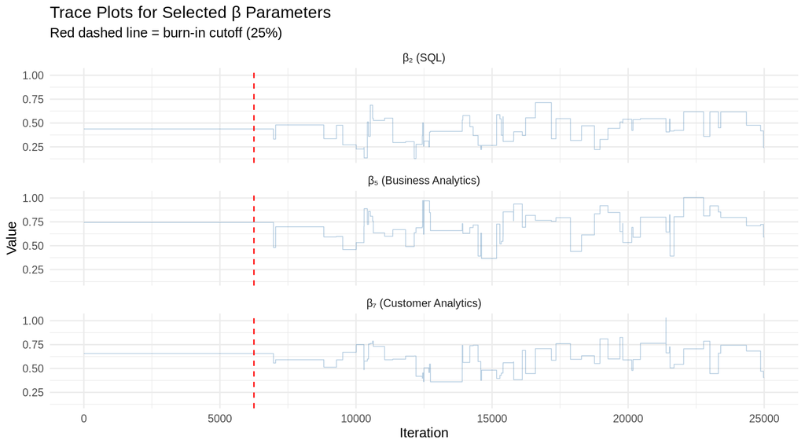

```r
# Trace plots for 3 parameters (β2, β5, β7)
trace_df <- as.data.frame(chain$draws) |>
  setNames(paste0("beta", 2:10)) |>
  mutate(iter = 1:n_iter) |>
  pivot_longer(-iter, names_to = "param", values_to = "value") |>
  filter(param %in% c("beta2", "beta5", "beta7"))

param_labs <- c(
  beta2 = "β₂ (SQL)",
  beta5 = "β₅ (Business Analytics)",
  beta7 = "β₇ (Customer Analytics)"
)

ggplot(trace_df, aes(x = iter, y = value)) +
  geom_line(alpha = 0.4, color = "steelblue", linewidth = 0.3) +
  geom_vline(xintercept = burn_in, color = "red", linetype = "dashed") +
  facet_wrap(~param, ncol = 1, labeller = labeller(param = param_labs)) +
  labs(
    title = "Trace Plots for Selected β Parameters",
    subtitle = "Red dashed line = burn-in cutoff (25%)",
    x = "Iteration", y = "Value"
  ) +
  theme_minimal(base_size = 11)
```

```r
# Full beta matrix with item 1 reference (column of zeros)
post_full <- cbind(0, post_draws)  # (18750 x 10)

# Posterior means and CIs for beta
beta_post_mean <- colMeans(post_full)
beta_post_ci   <- apply(post_full, 2, quantile, probs = c(0.025, 0.975))

# Posterior shares of preference (compute for each draw, then summarize)
# For each draw: shares = exp(beta) / sum(exp(beta))
compute_shares <- function(beta_vec) exp(beta_vec) / sum(exp(beta_vec))
post_shares    <- t(apply(post_full, 1, compute_shares))  # (n_draws x 10)

share_post_mean <- colMeans(post_shares)
share_post_ci   <- apply(post_shares, 2, quantile, probs = c(0.025, 0.975))

bayes_results <- labels |>
  mutate(
    beta_mean  = beta_post_mean,
    ci_lo_beta = beta_post_ci["2.5%", ],
    ci_hi_beta = beta_post_ci["97.5%", ],
    share_mean = share_post_mean,
    ci_lo_share = share_post_ci["2.5%", ],
    ci_hi_share = share_post_ci["97.5%", ]
  ) |>
  arrange(desc(share_mean))
```

```r
bayes_results |>
  mutate(
    beta_str  = sprintf("%.3f", beta_mean),
    ci_str    = sprintf("[%.3f, %.3f]", ci_lo_beta, ci_hi_beta),
    share_str = sprintf("%.4f", share_mean),
    ci_share_str = sprintf("[%.4f, %.4f]", ci_lo_share, ci_hi_share)
  ) |>
  select(item, short_label, beta_str, ci_str, share_str, ci_share_str) |>
  kable(
    col.names = c("Item #", "Class", "Post. Mean β", "95% CI (β)",
                  "Post. Mean Share", "95% CI (Share)"),
    caption = "Bayesian MNL: posterior means and 95% credible intervals"
  ) |>
  kable_styling(bootstrap_options = c("striped", "hover"), full_width = FALSE)
```

Bayesian MNL: posterior means and 95% credible intervals

| Item # | Class | Post. Mean β | 95% CI (β) | Post. Mean Share | 95% CI (Share) |
| --- | --- | --- | --- | --- | --- |
| 9 | Marketing Analytics | 1.601 | [1.380, 1.807] | 0.2811 | [0.2431, 0.3353] |
| 5 | Business Analytics | 0.708 | [0.367, 1.004] | 0.1155 | [0.0885, 0.1431] |
| 7 | Customer Analytics | 0.609 | [0.361, 0.786] | 0.1044 | [0.0860, 0.1211] |
| 4 | Large Data | 0.531 | [0.139, 0.951] | 0.0969 | [0.0742, 0.1201] |
| 2 | SQL | 0.450 | [0.228, 0.714] | 0.0891 | [0.0711, 0.1090] |
| 8 | Capstone | 0.434 | [0.211, 0.685] | 0.0876 | [0.0742, 0.1052] |
| 10 | BI Systems | 0.262 | [-0.015, 0.519] | 0.0738 | [0.0564, 0.0878] |
| 1 | AI Math & Prog. | 0.000 | [0.000, 0.000] | 0.0567 | [0.0464, 0.0647] |
| 3 | Mktg/Fin/Ops | -0.105 | [-0.277, 0.096] | 0.0511 | [0.0440, 0.0646] |
| 6 | Analytics Consulting | -0.261 | [-0.487, 0.001] | 0.0438 | [0.0356, 0.0569] |

```
`height` was translated to `width`.
```

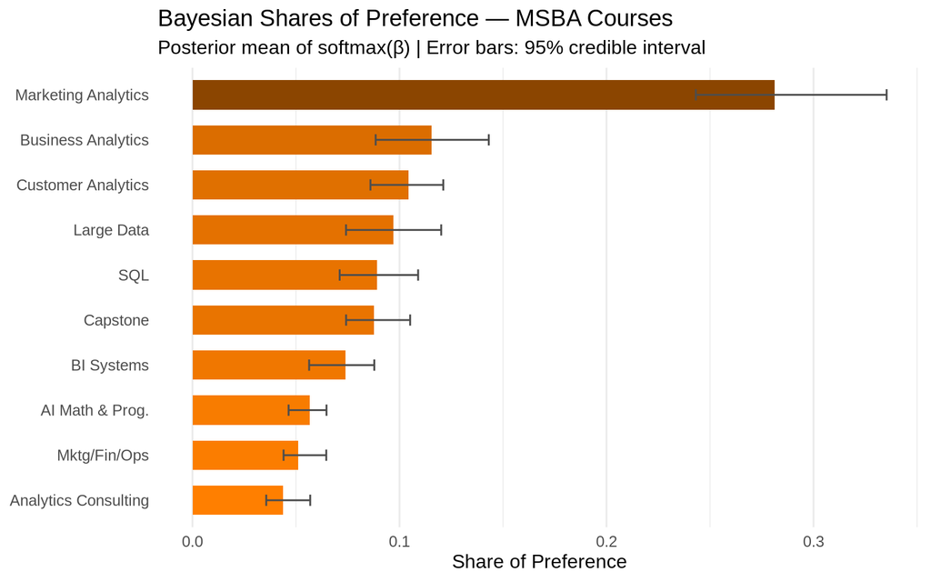

```r
bayes_results |>
  mutate(short_label = fct_reorder(short_label, share_mean)) |>
  ggplot(aes(x = share_mean, y = short_label)) +
  geom_col(aes(fill = share_mean), width = 0.65) +
  geom_errorbarh(
    aes(xmin = ci_lo_share, xmax = ci_hi_share),
    height = 0.25, color = "gray30"
  ) +
  scale_fill_gradient(low = "darkorange1", high = "darkorange4", guide = "none") +
  labs(
    title = "Bayesian Shares of Preference — MSBA Courses",
    subtitle = "Posterior mean of softmax(β) | Error bars: 95% credible interval",
    x = "Share of Preference",
    y = NULL
  ) +
  theme_minimal(base_size = 12) +
  theme(panel.grid.major.y = element_blank())
```

## Comparing the Three Methods

```r
# Merge all three results into one table
counts_ranked <- counts |>
  arrange(desc(score)) |>
  mutate(counts_rank = row_number()) |>
  select(item = Item, score, counts_rank)

mle_ranked <- mle_results |>
  arrange(desc(share)) |>
  mutate(mle_rank = row_number()) |>
  select(item, mle_share = share, mle_rank)

bayes_ranked <- bayes_results |>
  arrange(desc(share_mean)) |>
  mutate(bayes_rank = row_number()) |>
  select(item, bayes_share = share_mean, bayes_rank)

comparison <- labels |>
  left_join(counts_ranked, by = "item") |>
  left_join(mle_ranked,   by = "item") |>
  left_join(bayes_ranked, by = "item") |>
  arrange(mle_rank) |>
  mutate(
    score      = round(score, 3),
    mle_share  = round(mle_share, 4),
    bayes_share = round(bayes_share, 4)
  )

comparison |>
  select(short_label, score, counts_rank, mle_share, mle_rank, bayes_share, bayes_rank) |>
  kable(
    col.names = c("Class", "Counts Score", "Counts Rank",
                  "MLE Share", "MLE Rank", "Bayes Share", "Bayes Rank"),
    caption = "Side-by-side comparison of all three methods (sorted by MLE rank)"
  ) |>
  kable_styling(bootstrap_options = c("striped", "hover"), full_width = FALSE)
```

Side-by-side comparison of all three methods (sorted by MLE rank)

| Class | Counts Score | Counts Rank | MLE Share | MLE Rank | Bayes Share | Bayes Rank |
| --- | --- | --- | --- | --- | --- | --- |
| Marketing Analytics | 0.493 | 1 | 0.2839 | 1 | 0.2811 | 1 |
| Business Analytics | 0.141 | 2 | 0.1171 | 2 | 0.1155 | 2 |
| Customer Analytics | 0.120 | 3 | 0.1072 | 3 | 0.1044 | 3 |
| Large Data | 0.062 | 4 | 0.0969 | 4 | 0.0969 | 4 |
| Capstone | 0.011 | 5 | 0.0867 | 5 | 0.0876 | 6 |
| SQL | -0.004 | 6 | 0.0862 | 6 | 0.0891 | 5 |
| BI Systems | -0.120 | 7 | 0.0704 | 7 | 0.0738 | 7 |
| AI Math & Prog. | -0.209 | 8 | 0.0556 | 8 | 0.0567 | 8 |
| Mktg/Fin/Ops | -0.213 | 9 | 0.0520 | 9 | 0.0511 | 9 |
| Analytics Consulting | -0.292 | 10 | 0.0438 | 10 | 0.0438 | 10 |

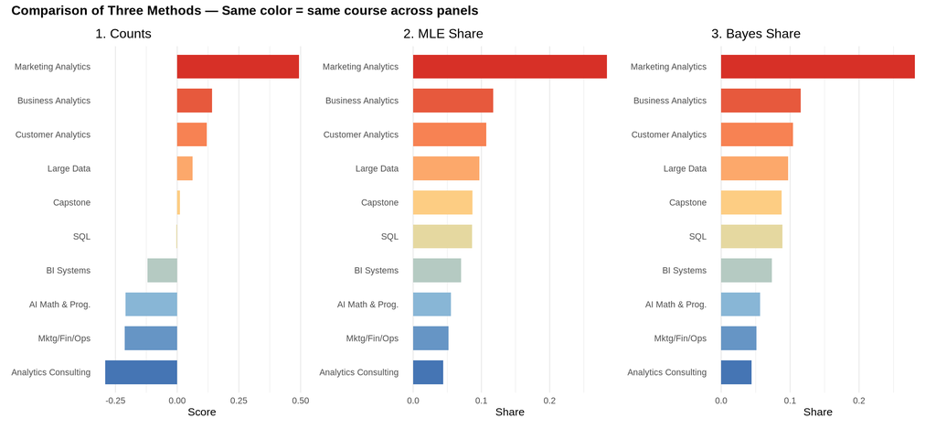

```r
# Three-panel bar chart with consistent coloring
item_order_mle <- mle_results |> arrange(share) |> pull(short_label)
color_map <- setNames(
  colorRampPalette(c("#d73027","#fc8d59","#fee090","#91bfdb","#4575b4"))(10),
  rev(item_order_mle)
)

p_counts <- comparison |>
  mutate(short_label = factor(short_label, levels = item_order_mle)) |>
  ggplot(aes(x = score, y = short_label, fill = short_label)) +
  geom_col(width = 0.7) +
  scale_fill_manual(values = color_map, guide = "none") +
  labs(title = "1. Counts", x = "Score", y = NULL) +
  theme_minimal(base_size = 10) +
  theme(panel.grid.major.y = element_blank())

p_mle <- comparison |>
  mutate(short_label = factor(short_label, levels = item_order_mle)) |>
  ggplot(aes(x = mle_share, y = short_label, fill = short_label)) +
  geom_col(width = 0.7) +
  scale_fill_manual(values = color_map, guide = "none") +
  labs(title = "2. MLE Share", x = "Share", y = NULL) +
  theme_minimal(base_size = 10) +
  theme(panel.grid.major.y = element_blank())

p_bayes <- comparison |>
  mutate(short_label = factor(short_label, levels = item_order_mle)) |>
  ggplot(aes(x = bayes_share, y = short_label, fill = short_label)) +
  geom_col(width = 0.7) +
  scale_fill_manual(values = color_map, guide = "none") +
  labs(title = "3. Bayes Share", x = "Share", y = NULL) +
  theme_minimal(base_size = 10) +
  theme(panel.grid.major.y = element_blank())

library(patchwork)
p_counts + p_mle + p_bayes +
  plot_annotation(
    title = "Comparison of Three Methods — Same color = same course across panels",
    theme = theme(plot.title = element_text(size = 12, face = "bold"))
  )
```

**Discussion of the comparison:**

*What does MNL add over counts?* The MNL model explicitly accounts for the choice set — not just “was this item picked?” but “given the alternatives it was shown with, how surprising is the pick?” A course that was repeatedly shown alongside very strong competitors and still got picked a reasonable fraction of the time will get a higher MLE utility than its counts score alone would suggest.

*What does Bayes add over MLE?* The Bayesian approach makes it trivial to compute credible intervals on nonlinear functions of $\boldsymbol{\beta}$, like the shares of preference. We simply compute the shares for every MCMC draw and take quantiles — no delta method needed. If we wanted to ask “how confident are we that Customer Analytics beats Business Analytics?”, Bayes answers this directly: count the fraction of draws where $\beta_7 > \beta_5$.

## Discussion

**Which method for which question?**

- **Counts analysis** is ideal for a quick executive dashboard or a first look at the data. It takes seconds to compute and produces an instantly interpretable score. Its weakness is that it ignores the competitive context of each task.
- **MLE MNL** is the right choice when you need a single, statistically rigorous number to report — e.g., to compare two courses formally with a standard error, or to input into a downstream market simulation. It is fast to optimize and provides Hessian-based standard errors.
- **Bayesian MNL** shines when you want uncertainty on derived quantities (shares, differences between courses, “what if we removed one class?” scenarios) without approximation, or when you want to extend the model hierarchically to estimate *individual-level* preferences. Here, the posterior means and MLE estimates are nearly identical due to the large dataset, but the Bayesian framework would become decisive in smaller samples or more complex models.

**Caveats:** The survey was taken by a self-selected sample of MSBA students who may differ from future cohorts. Preferences are likely shaped by prior coursework, current quarter in the program, and familiarity with the faculty — none of which we can control for with aggregate data.

**What’s next?** With more time, I would fit a **hierarchical (mixed) MNL model** to estimate individual-level $\beta_j$’s, allowing us to segment students into preference clusters (e.g., “quant-focused” vs. “applied” learners). I would also explore whether preferences differ by prior background (CS vs. business undergrad) or quarter in the program.